# Network analysis - *manta* and *anuran*

Sam Rottjers

# Network analysis - clusters

In this tutorial, we will look at the Axinellida network with manta. You can install manta following the instructions on the Github: [manta Github repository](https://github.com/ramellose/manta).

## Step 1 - Data

For this tutorial, we will use the networks from the FlashWeave tutorial: [Running FlashWeave on sponge networks](https://ramellose.github.io/networktutorials/running_flashweave.html).  
If you were unable to run FlashWeave, please find the networks here: [ZIP file with networks](https://github.com/ramellose/networktutorials/blob/master/Workshop%202021/sponges_networks.zip).

The Axinellida network is shown below. Negatively-weighted edges are coloured blue, the positively-weighted edges are in red.

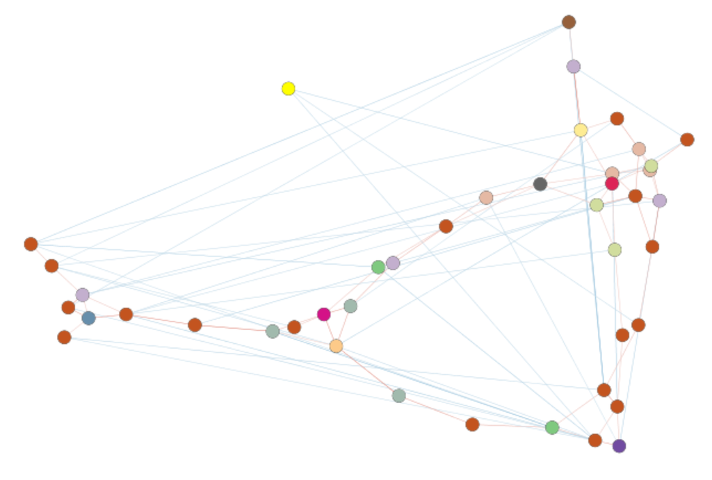

## Step 2 - Checking your installation

Open your terminal and check if your *manta* installation works by running the help command. If you have correctly installed *manta*, you should get an explanation of all the parameters.

```r
manta -h
```

## Step 3 - Running *manta* on the SPIEC-EASI and FlashWeave networks

There are two ways to import networks with *manta*: either you specify the complete file path, or you navigate to the directory where you saved the graphml files. Try navigating to the directory, since it will save you a lot of typing! Unfamiliar with command line? Check the [solutions](https://ramellose.github.io/networktutorials/workshop_manta_answers.html#cmd).

Now that you are in the right location, run *manta*. Only the -i and -o parameters are mandatory; other parameters implement different features or set parameters of the clustering algorithm itself. With the --layout flag, the software will generate a layout as well, so the graph will be organized by cluster if it is imported into Cytoscape.

```r
manta -i Axinellida.graphml -o Axinellida_clustered --layout
```

Several flags affect how manta clusters the algorithm. These include -cr and -b. Unfortunately, the -cr flag does not work very well because these networks are so small, but we can see what happens when we use the -b flag. What do you think that the -b flag does? [Solution.](https://ramellose.github.io/networktutorials/workshop_manta_answers.html#manta)

```r
manta -i Axinellida.graphml -o Axinellida_clustered --layout -b
```

Can you try running manta on other sponge networks? Do any of them appear to have obvious clusters? Several different clustering algorithsm are implemented in NetworkX and igraph. For example, we could try to run the walktrap clustering algorithm: [cluster_walktrap manual page](https://igraph.org/r/doc/cluster_walktrap.html). Try running this and other algorithms to see how these clusters are different!

[Back to overview](https://ramellose.github.io/networktutorials/overview_workshop.html)